# Representation by District

# Member characteristics

## Congressional record parsed by speaker

Directory structure of the data/txt folder:

```r
cr_file <- list.files(here::here("data", "txt") %>%
                        str_replace("redistricting", "Congressional records/cr"),
                      recursive = T)

tibble(file = cr_file) %>% kablebox()
```

| file |
| --- |
| 2018/14871/CREC-2018-10-03-pt1-PgS6492-000004-14871.txt |
| 2018/14871/CREC-2018-10-11-pt1-PgS6809-2-000017-14871.txt |
| 2018/14921/CREC-2018-10-05-pt2-PgS6698-2-000009-14921.txt |
| 2018/14921/CREC-2018-10-05-pt2-PgS6698-2-000010-14921.txt |
| 2018/14921/CREC-2018-10-11-pt1-PgS6880-3-000018-14921.txt |
| 2018/14921/CREC-2018-10-11-pt1-PgS6880-3-000019-14921.txt |
| 2018/14921/CREC-2018-10-11-pt1-PgS6880-3-000020-14921.txt |
| 2018/15029/CREC-2018-11-13-pt1-PgH9508-4-000043-15029.txt |
| 2018/15029/CREC-2018-11-13-pt1-PgH9508-4-000044-15029.txt |
| 2018/15603/CREC-2018-11-09-pt1-PgE1501-2-000014-15603.txt |
| 2018/15603/CREC-2018-11-09-pt1-PgE1501-2-000015-15603.txt |
| 2018/20124/CREC-2018-10-23-pt1-PgE1441-3-000028-20124.txt |
| 2018/20124/CREC-2018-10-23-pt1-PgE1441-3-000029-20124.txt |
| 2018/20352/CREC-2018-11-14-pt1-PgH9525-000064-20352.txt |
| 2018/20352/CREC-2018-11-14-pt1-PgH9525-000065-20352.txt |
| 2018/20352/CREC-2018-11-14-pt1-PgH9525-000066-20352.txt |
| 2018/20352/CREC-2018-11-14-pt1-PgH9525-000067-20352.txt |
| 2018/20501/CREC-2018-10-16-pt1-PgE1417-000024-20501.txt |
| 2018/20501/CREC-2018-10-16-pt1-PgE1417-000025-20501.txt |
| 2018/20501/CREC-2018-11-09-pt1-PgE1506-2-000016-20501.txt |
| 2018/20501/CREC-2018-11-09-pt1-PgE1506-2-000017-20501.txt |
| 2018/20518/CREC-2018-11-02-pt1-PgE1485-2-000001-20518.txt |
| 2018/20518/CREC-2018-11-02-pt1-PgE1485-2-000002-20518.txt |
| 2018/20521/CREC-2018-11-13-pt1-PgH9474-000028-20521.txt |
| 2018/20521/CREC-2018-11-13-pt1-PgH9474-000029-20521.txt |
| 2018/20521/CREC-2018-11-13-pt1-PgH9507-000046-20521.txt |
| 2018/20528/CREC-2018-11-02-pt1-PgE1491-7-000005-20528.txt |
| 2018/20528/CREC-2018-11-02-pt1-PgE1491-7-000006-20528.txt |
| 2018/20705/CREC-2018-10-30-pt1-PgE1481-4-000034-20705.txt |
| 2018/20705/CREC-2018-10-30-pt1-PgE1481-4-000035-20705.txt |

[output cut: 70 more lines]

## Merge in voteview data

by Congress and legislator ICPSR identifier linking to variables including:

- DW-NOMINATE spatial ideology scores based on voting record (`nominate.dim1`, `nominate.dim2`)
- `party_size`

```r
d <- tibble(file = cr_file %>% str_remove(".*/"),
            speech_id = cr_file %>% str_extract("000[0-9]*"),
            icpsr = str_remove(cr_file, ".*-") %>%
              str_remove(".txt") %>%
              as.integer(),
            date = str_extract(cr_file, "CREC-[0-9]*-[0-9]*-[0-9]*") %>%
              str_remove("CREC-") %>%
              as.Date)

d %<>% filter(!is.na(icpsr))

# get congress from year
d %<>% mutate(year = str_sub(date, 1,4) %>% as.integer()) # the 107th congress began in 2001

# get congress from year
d %<>% mutate(congress = as.numeric(round((year - 2001.1)/2)) + 107) # the 107th congress began in 2001

# Devin's members data (expanded from voteview)
load(here("data", "members.Rdata"))

d %<>% left_join(members)

# count speeches per member
d %<>% group_by(icpsr) %>% add_count(name = "speeches_n")

# drop name varients
d %<>% select(-contains("first"), -contains("common"), -contains("middle"), -contains("last"), -contains("maiden"), -pattern)

speeches <- d %>% distinct(icpsr, file, speech_id, speeches_n, date, year, congress, chamber, bioname)

d %>%
  select(bioname, cqlabel, icpsr, file) %>%
  distinct() %>%
  kablebox()
```

| bioname | cqlabel | icpsr | file |
| --- | --- | --- | --- |
| WYDEN, Ronald Lee | (OR) | 14871 | CREC-2018-10-03-pt1-PgS6492-000004-14871.txt |
| WYDEN, Ronald Lee | (OR) | 14871 | CREC-2018-10-11-pt1-PgS6809-2-000017-14871.txt |
| McCONNELL, Addison Mitchell (Mitch) | (KY) | 14921 | CREC-2018-10-05-pt2-PgS6698-2-000009-14921.txt |
| McCONNELL, Addison Mitchell (Mitch) | (KY) | 14921 | CREC-2018-10-05-pt2-PgS6698-2-000010-14921.txt |
| McCONNELL, Addison Mitchell (Mitch) | (KY) | 14921 | CREC-2018-10-11-pt1-PgS6880-3-000018-14921.txt |
| McCONNELL, Addison Mitchell (Mitch) | (KY) | 14921 | CREC-2018-10-11-pt1-PgS6880-3-000019-14921.txt |
| McCONNELL, Addison Mitchell (Mitch) | (KY) | 14921 | CREC-2018-10-11-pt1-PgS6880-3-000020-14921.txt |
| KAPTUR, Marcia Carolyn (Marcy) | (OH-09) | 15029 | CREC-2018-11-13-pt1-PgH9508-4-000043-15029.txt |
| KAPTUR, Marcia Carolyn (Marcy) | (OH-09) | 15029 | CREC-2018-11-13-pt1-PgH9508-4-000044-15029.txt |
| ENGEL, Eliot Lance | (NY-16) | 15603 | CREC-2018-11-09-pt1-PgE1501-2-000014-15603.txt |
| ENGEL, Eliot Lance | (NY-16) | 15603 | CREC-2018-11-09-pt1-PgE1501-2-000015-15603.txt |
| GRAVES, Samuel | (MO-06) | 20124 | CREC-2018-10-23-pt1-PgE1441-3-000028-20124.txt |
| GRAVES, Samuel | (MO-06) | 20124 | CREC-2018-10-23-pt1-PgE1441-3-000029-20124.txt |
| HENSARLING, Jeb | (TX-05) | 20352 | CREC-2018-11-14-pt1-PgH9525-000064-20352.txt |
| HENSARLING, Jeb | (TX-05) | 20352 | CREC-2018-11-14-pt1-PgH9525-000065-20352.txt |
| HENSARLING, Jeb | (TX-05) | 20352 | CREC-2018-11-14-pt1-PgH9525-000066-20352.txt |
| HENSARLING, Jeb | (TX-05) | 20352 | CREC-2018-11-14-pt1-PgH9525-000067-20352.txt |
| COSTA, Jim | (CA-16) | 20501 | CREC-2018-10-16-pt1-PgE1417-000024-20501.txt |
| COSTA, Jim | (CA-16) | 20501 | CREC-2018-10-16-pt1-PgE1417-000025-20501.txt |
| COSTA, Jim | (CA-16) | 20501 | CREC-2018-11-09-pt1-PgE1506-2-000016-20501.txt |
| COSTA, Jim | (CA-16) | 20501 | CREC-2018-11-09-pt1-PgE1506-2-000017-20501.txt |
| FORTENBERRY, Jeff | (NE-01) | 20518 | CREC-2018-11-02-pt1-PgE1485-2-000001-20518.txt |
| FORTENBERRY, Jeff | (NE-01) | 20518 | CREC-2018-11-02-pt1-PgE1485-2-000002-20518.txt |
| FOXX, Virginia Ann | (NC-05) | 20521 | CREC-2018-11-13-pt1-PgH9474-000028-20521.txt |
| FOXX, Virginia Ann | (NC-05) | 20521 | CREC-2018-11-13-pt1-PgH9474-000029-20521.txt |
| FOXX, Virginia Ann | (NC-05) | 20521 | CREC-2018-11-13-pt1-PgH9507-000046-20521.txt |
| POE, Ted | (TX-02) | 20528 | CREC-2018-11-02-pt1-PgE1491-7-000005-20528.txt |
| POE, Ted | (TX-02) | 20528 | CREC-2018-11-02-pt1-PgE1491-7-000006-20528.txt |
| PERLMUTTER, Ed | (CO-07) | 20705 | CREC-2018-10-30-pt1-PgE1481-4-000034-20705.txt |
| PERLMUTTER, Ed | (CO-07) | 20705 | CREC-2018-10-30-pt1-PgE1481-4-000035-20705.txt |

[output cut: 70 more lines]

## Subset to Wisconsin and Texas House Reps

```r
# House members from WI
d %<>% filter(state %in% c("wisconsin", "texas"),
             chamber == "House")




d %>%
  select(bioname, cqlabel, icpsr, file) %>%
  distinct() %>%
  kablebox()
```

| bioname | cqlabel | icpsr | file |
| --- | --- | --- | --- |
| HENSARLING, Jeb | (TX-05) | 20352 | CREC-2018-11-14-pt1-PgH9525-000064-20352.txt |
| HENSARLING, Jeb | (TX-05) | 20352 | CREC-2018-11-14-pt1-PgH9525-000065-20352.txt |
| HENSARLING, Jeb | (TX-05) | 20352 | CREC-2018-11-14-pt1-PgH9525-000066-20352.txt |
| HENSARLING, Jeb | (TX-05) | 20352 | CREC-2018-11-14-pt1-PgH9525-000067-20352.txt |
| POE, Ted | (TX-02) | 20528 | CREC-2018-11-02-pt1-PgE1491-7-000005-20528.txt |
| POE, Ted | (TX-02) | 20528 | CREC-2018-11-02-pt1-PgE1491-7-000006-20528.txt |
| MOORE, Gwendolynne S. (Gwen) | (WI-04) | 20537 | CREC-2020-07-09-pt1-PgH3078-6-000108-20537.txt |
| OLSON, Pete | (TX-22) | 20948 | CREC-2020-04-22-pt1-PgE380-3-000031-20948.txt |
| OLSON, Pete | (TX-22) | 20948 | CREC-2020-04-22-pt1-PgE380-3-000032-20948.txt |
| CASTRO, Joaquin | (TX-20) | 21362 | CREC-2020-04-22-pt1-PgH1904-5-000033-21362.txt |
| CASTRO, Joaquin | (TX-20) | 21362 | CREC-2020-04-22-pt1-PgH1904-5-000034-21362.txt |
| CASTRO, Joaquin | (TX-20) | 21362 | CREC-2020-04-22-pt1-PgH1904-5-000035-21362.txt |
| CASTRO, Joaquin | (TX-20) | 21362 | CREC-2020-04-22-pt1-PgH1904-5-000036-21362.txt |
| CASTRO, Joaquin | (TX-20) | 21362 | CREC-2020-04-22-pt1-PgH1904-5-000037-21362.txt |
| CASTRO, Joaquin | (TX-20) | 21362 | CREC-2020-04-22-pt1-PgH1904-5-000038-21362.txt |
| CASTRO, Joaquin | (TX-20) | 21362 | CREC-2020-04-22-pt1-PgH1904-5-000039-21362.txt |
| BABIN, Brian | (TX-36) | 21551 | CREC-2020-02-06-pt1-PgE140-4-000014-21551.txt |
| BABIN, Brian | (TX-36) | 21551 | CREC-2020-02-06-pt1-PgE140-4-000015-21551.txt |
| ARRINGTON, Jodey Cook | (TX-19) | 21700 | CREC-2020-06-11-pt1-PgH2389-7-000158-21700.txt |
| GOODEN, Lance | (TX-05) | 21925 | CREC-2020-04-03-pt1-PgH1876-3-000004-21925.txt |

TODO

- identify WI House members who were up for reelection in 2020
- measure gregariousness (frequency of speeches)
- measure *level* of attention to their district (mentions of their home state, district, etc.)
- measure *ratio*/log odds of “my district” vs “my conscience” etc.

# District characteristics

## Connectivity

- [Facebook friendships](https://github.com/judgelord/redistricting/blob/main/data/WI_congress_facebook_sci_pop.txt) (`facebook_sci`)
- [Travel](https://github.com/judgelord/redistricting/blob/main/data/district_flows_safegraph.txt) (`flow_count`)

We measure travel in two ways:

- Flows between districts (`flow_count`, the top figure below)
- Flows between districts to and from bordering census blocks, (`flow_count_border`, the bottom figure below)

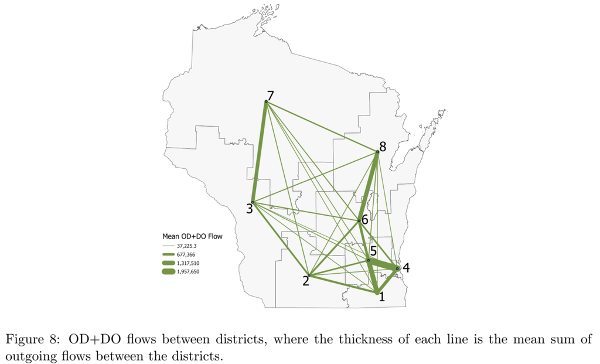

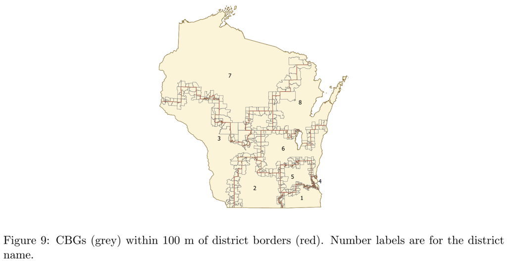

```r
include_graphics(here("figs", "flow.png"))
include_graphics(here("figs", "flow-CBG.png"))
```

There are three values for each measure of connectivity (facebook friendships, travel,and near-border travel):

- within-district
- `out`-of-district
- the `ratio` of within-district to out-of-district

```r
# facebook friend data
fb <- read_csv(here::here("data", "WI_congress_facebook_sci_pop.txt"))  %>%
  mutate_all(as.integer) %>%
  mutate(state = "wisconsin")

names(fb) %<>% str_remove("_C.*")

# cell phone mobility data
flow <- read_csv(here::here("data", "WI_DistrictFlows_January_2020.csv")) %>%
                   mutate(state = "wisconsin")  %>%
  full_join(read_csv(here::here("data", "TX_DistrictFlows_January_2020.csv")) %>%
              mutate(state = "texas"))

flow_border <- read_csv(here::here("data", "WI_DistrictFlows_BorderCBGs_January_2020.csv")) %>%
                   mutate(state = "wisconsin")  %>%
  full_join(read_csv(here::here("data", "TX_DistrictFlows_BorderCBGs_January_2020.csv")) %>%
              mutate(state = "texas")) %>%
  rename(Flow_Count_Border = Flow_Count)

flow %<>%
  full_join(flow_border) %>%
  mutate(OD_Pairs = OD_Pairs %>% str_remove_all("\\(|\\)")) %>%
  separate(OD_Pairs, into = c("from", "to"), sep = ", ") %>%
  mutate(across(c(from, to), as.integer))

# names to match facebook data
names(flow) %<>% str_to_lower()

c <- full_join(fb, flow) %>% select(state, everything())

within <- c %>% filter(from == to)

out <- c %>% filter(from != to) %>%
  select(-to) %>%
  group_by(state, from) %>%
  summarise_all(sum)

flows <- full_join(within, out, by = c("state", "from"), suffix = c("", "_out")) %>%
  mutate(facebook_sci_ratio = facebook_sci/facebook_sci_out,
         flow_ratio = flow_count/flow_count_out,
         flow_ratio_border = flow_count_border/flow_count_border_out
         ) %>%
  rename(district_code = from) %>%
  select(state, everything(), -to )

flows %>% kablebox()
```

| state | district_code | facebook_sci | flow_count | flow_count_border | facebook_sci_out | flow_count_out | flow_count_border_out | facebook_sci_ratio | flow_ratio | flow_ratio_border |
| --- | --- | --- | --- | --- | --- | --- | --- | --- | --- | --- |
| wisconsin | 3 | 850188 | 3968910 | 536612 | 707114 | 882239 | 256509 | 1.2023351 | 4.4986789 | 2.0919812 |
| wisconsin | 7 | 803742 | 3637086 | 317339 | 640362 | 685039 | 211594 | 1.2551369 | 5.3093123 | 1.4997542 |
| wisconsin | 8 | 995091 | 5062438 | 427400 | 784984 | 848245 | 204504 | 1.2676577 | 5.9681318 | 2.0899347 |
| wisconsin | 6 | 933867 | 4024884 | 584179 | 1083714 | 1528513 | 446415 | 0.8617283 | 2.6332023 | 1.3086007 |
| wisconsin | 2 | 765383 | 4336161 | 304703 | 376776 | 878954 | 176815 | 2.0314006 | 4.9333196 | 1.7232871 |
| wisconsin | 5 | 515978 | 4686964 | 996047 | 794622 | 1733938 | 644484 | 0.6493377 | 2.7030747 | 1.5454953 |
| wisconsin | 1 | 626152 | 4452396 | 354047 | 628966 | 1558898 | 416712 | 0.9955260 | 2.8561176 | 0.8496204 |
| wisconsin | 4 | 1088428 | 4389604 | 667951 | 180506 | 2103750 | 620362 | 6.0298716 | 2.0865616 | 1.0767117 |
| texas | 1 | NA | 6786158 | 1034834 | NA | 1607086 | 374052 | NA | 4.2226477 | 2.7665512 |
| texas | 2 | NA | 3906385 | 1932209 | NA | 5103014 | 3012360 | NA | 0.7655054 | 0.6414270 |
| texas | 3 | NA | 6596739 | 730766 | NA | 2957487 | 660102 | NA | 2.2305217 | 1.1070501 |
| texas | 4 | NA | 5404387 | 944550 | NA | 2744095 | 984844 | NA | 1.9694606 | 0.9590859 |
| texas | 5 | NA | 4465371 | 1182073 | NA | 3951303 | 1514025 | NA | 1.1301009 | 0.7807487 |
| texas | 6 | NA | 5114884 | 1226365 | NA | 3775350 | 1470252 | NA | 1.3548105 | 0.8341189 |
| texas | 7 | NA | 4118559 | 1781930 | NA | 4413863 | 2268134 | NA | 0.9330962 | 0.7856370 |
| texas | 8 | NA | 5718536 | 1147474 | NA | 3722462 | 1550046 | NA | 1.5362241 | 0.7402838 |
| texas | 9 | NA | 3553740 | 1124302 | NA | 4314167 | 1854393 | NA | 0.8237372 | 0.6062911 |
| texas | 10 | NA | 3634491 | 1600028 | NA | 4602216 | 2660474 | NA | 0.7897263 | 0.6014071 |
| texas | 11 | NA | 6258935 | 753254 | NA | 2066954 | 639409 | NA | 3.0280959 | 1.1780472 |
| texas | 12 | NA | 5627826 | 1297504 | NA | 3691727 | 1286735 | NA | 1.5244426 | 1.0083692 |
| texas | 13 | NA | 6002440 | 464129 | NA | 1296193 | 387041 | NA | 4.6308227 | 1.1991727 |
| texas | 14 | NA | 5501517 | 650763 | NA | 2587887 | 603803 | NA | 2.1258722 | 1.0777737 |
| texas | 15 | NA | 5915005 | 1756487 | NA | 3199594 | 1532321 | NA | 1.8486736 | 1.1462918 |
| texas | 16 | NA | 5532866 | 700821 | NA | 552399 | 122707 | NA | 10.0160681 | 5.7113368 |
| texas | 17 | NA | 5675186 | 844024 | NA | 2790294 | 1051511 | NA | 2.0339025 | 0.8026773 |
| texas | 18 | NA | 3354833 | 1107211 | NA | 4439764 | 1866130 | NA | 0.7556332 | 0.5933193 |
| texas | 19 | NA | 7055603 | 469162 | NA | 1376549 | 187738 | NA | 5.1255734 | 2.4990252 |
| texas | 20 | NA | 5115287 | 1460108 | NA | 3604746 | 1269960 | NA | 1.4190423 | 1.1497276 |
| texas | 21 | NA | 4093907 | 1698184 | NA | 4092386 | 2258580 | NA | 1.0003717 | 0.7518813 |
| texas | 22 | NA | 4477506 | 1664592 | NA | 4356329 | 2132982 | NA | 1.0278163 | 0.7804060 |
| texas | 23 | NA | 3555943 | 1315660 | NA | 4182775 | 2150673 | NA | 0.8501397 | 0.6117434 |
| texas | 24 | NA | 4783658 | 981213 | NA | 3722186 | 1120792 | NA | 1.2851744 | 0.8754640 |
| texas | 25 | NA | 3689933 | 1398412 | NA | 4304929 | 2191617 | NA | 0.8571414 | 0.6380732 |
| texas | 26 | NA | 5561482 | 803567 | NA | 4156326 | 1050628 | NA | 1.3380765 | 0.7648445 |
| texas | 27 | NA | 6178512 | 617330 | NA | 1844275 | 561505 | NA | 3.3501034 | 1.0994203 |
| texas | 28 | NA | 5680399 | 1659209 | NA | 3332282 | 1484054 | NA | 1.7046573 | 1.1180247 |
| texas | 29 | NA | 4094408 | 1471072 | NA | 4487356 | 1950581 | NA | 0.9124322 | 0.7541712 |
| texas | 30 | NA | 3931457 | 870416 | NA | 3817296 | 1417626 | NA | 1.0299062 | 0.6139955 |
| texas | 31 | NA | 5855121 | 847128 | NA | 2546524 | 493872 | NA | 2.2992601 | 1.7152785 |
| texas | 32 | NA | 4571799 | 1327859 | NA | 3891268 | 1449991 | NA | 1.1748867 | 0.9157705 |
| texas | 33 | NA | 3333896 | 1260341 | NA | 4633828 | 2127076 | NA | 0.7194691 | 0.5925228 |
| texas | 34 | NA | 5812647 | 1032763 | NA | 2589182 | 1040056 | NA | 2.2449743 | 0.9929879 |
| texas | 35 | NA | 3586225 | 1892224 | NA | 4665742 | 2839085 | NA | 0.7686291 | 0.6664908 |
| texas | 36 | NA | 4982044 | 858822 | NA | 3677391 | 967782 | NA | 1.3547768 | 0.8874127 |

### Merge in connectivity

```r
d2 <- d %>%
  left_join(flows) %>%
  filter(!is.na(flow_count))

# number of speeches
d2 %>% distinct(bioname, cqlabel,
                flow_count, flow_count_out, flow_count_border, flow_count, flow_count_border_out, flow_ratio_border, facebook_sci, facebook_sci_out,facebook_sci_ratio, speeches_n) %>% kablebox()
```

| icpsr | bioname | cqlabel | speeches_n | facebook_sci | flow_count | flow_count_border | facebook_sci_out | flow_count_out | flow_count_border_out | facebook_sci_ratio | flow_ratio_border |
| --- | --- | --- | --- | --- | --- | --- | --- | --- | --- | --- | --- |
| 20352 | HENSARLING, Jeb | (TX-05) | 4 | NA | 4465371 | 1182073 | NA | 3951303 | 1514025 | NA | 0.7807487 |
| 20528 | POE, Ted | (TX-02) | 2 | NA | 3906385 | 1932209 | NA | 5103014 | 3012360 | NA | 0.6414270 |
| 20537 | MOORE, Gwendolynne S. (Gwen) | (WI-04) | 1 | 1088428 | 4389604 | 667951 | 180506 | 2103750 | 620362 | 6.029872 | 1.0767117 |
| 20948 | OLSON, Pete | (TX-22) | 2 | NA | 4477506 | 1664592 | NA | 4356329 | 2132982 | NA | 0.7804060 |
| 21362 | CASTRO, Joaquin | (TX-20) | 7 | NA | 5115287 | 1460108 | NA | 3604746 | 1269960 | NA | 1.1497276 |
| 21551 | BABIN, Brian | (TX-36) | 2 | NA | 4982044 | 858822 | NA | 3677391 | 967782 | NA | 0.8874127 |
| 21700 | ARRINGTON, Jodey Cook | (TX-19) | 1 | NA | 7055603 | 469162 | NA | 1376549 | 187738 | NA | 2.4990252 |
| 21925 | GOODEN, Lance | (TX-05) | 1 | NA | 4465371 | 1182073 | NA | 3951303 | 1514025 | NA | 0.7807487 |

## Demographics

```r
dem <- read_csv(here::here("data", "CD_DEMO_DATA", "115CD_DEMOGRAPHIC_SUMMARY_ACS_2010_CENSUS_1YR_EST.csv"))

# the first 4 rows are metadata for values
dem_names <- head(dem, 4)

# pivot value names
dem_names %<>%
  mutate(NAME = c("format", "type", "measure", "group") ) %>%
  group_by(NAME) %>%
  pivot_longer(!NAME) %>%
  ungroup() %>%
  pivot_wider(names_from = NAME)

# pivot data
dem %<>%
  group_by(NAME, GEO_ID) %>%
  pivot_longer(starts_with("SF")) %>%
  mutate(state = str_remove(NAME, ".*, ") %>% str_to_lower(),
         district_code = str_extract(NAME, "District [0-9]*") %>%
           str_remove("District ") %>% as.numeric()) %>%
  # drop non-values
  mutate(value = as.numeric(value)) %>% filter(!is.na(value)) %>%
  #join value names
  left_join(dem_names) %>%
  rename(district_name = NAME)

# demographic variables
dem %>%
  distinct(type, measure, group) %>%
  kablebox()
```

| GEO_ID | district_name | type | measure | group |
| --- | --- | --- | --- | --- |
| 5001500US4823 | Congressional District 23 (115th Congress), Texas | SEX AND AGE | Total population | NA |
| 5001500US4823 | Congressional District 23 (115th Congress), Texas | SEX AND AGE | Total population | Under 5 years |
| 5001500US4823 | Congressional District 23 (115th Congress), Texas | SEX AND AGE | Total population | 5 to 9 years |
| 5001500US4823 | Congressional District 23 (115th Congress), Texas | SEX AND AGE | Total population | 10 to 14 years |
| 5001500US4823 | Congressional District 23 (115th Congress), Texas | SEX AND AGE | Total population | 15 to 19 years |
| 5001500US4823 | Congressional District 23 (115th Congress), Texas | SEX AND AGE | Total population | 20 to 24 years |
| 5001500US4823 | Congressional District 23 (115th Congress), Texas | SEX AND AGE | Total population | 25 to 29 years |
| 5001500US4823 | Congressional District 23 (115th Congress), Texas | SEX AND AGE | Total population | 30 to 34 years |
| 5001500US4823 | Congressional District 23 (115th Congress), Texas | SEX AND AGE | Total population | 35 to 39 years |
| 5001500US4823 | Congressional District 23 (115th Congress), Texas | SEX AND AGE | Total population | 40 to 44 years |
| 5001500US4823 | Congressional District 23 (115th Congress), Texas | SEX AND AGE | Total population | 45 to 49 years |
| 5001500US4823 | Congressional District 23 (115th Congress), Texas | SEX AND AGE | Total population | 50 to 54 years |
| 5001500US4823 | Congressional District 23 (115th Congress), Texas | SEX AND AGE | Total population | 55 to 59 years |
| 5001500US4823 | Congressional District 23 (115th Congress), Texas | SEX AND AGE | Total population | 60 to 64 years |
| 5001500US4823 | Congressional District 23 (115th Congress), Texas | SEX AND AGE | Total population | 65 to 69 years |
| 5001500US4823 | Congressional District 23 (115th Congress), Texas | SEX AND AGE | Total population | 70 to 74 years |
| 5001500US4823 | Congressional District 23 (115th Congress), Texas | SEX AND AGE | Total population | 75 to 79 years |
| 5001500US4823 | Congressional District 23 (115th Congress), Texas | SEX AND AGE | Total population | 80 to 84 years |
| 5001500US4823 | Congressional District 23 (115th Congress), Texas | SEX AND AGE | Total population | 85 years and over |
| 5001500US4823 | Congressional District 23 (115th Congress), Texas | SEX AND AGE | Total population | Median age (years) |
| 5001500US4823 | Congressional District 23 (115th Congress), Texas | SEX AND AGE | Total population | 16 years and over |
| 5001500US4823 | Congressional District 23 (115th Congress), Texas | SEX AND AGE | Total population | 18 years and over |
| 5001500US4823 | Congressional District 23 (115th Congress), Texas | SEX AND AGE | Total population | 21 years and over |
| 5001500US4823 | Congressional District 23 (115th Congress), Texas | SEX AND AGE | Total population | 62 years and over |
| 5001500US4823 | Congressional District 23 (115th Congress), Texas | SEX AND AGE | Total population | 65 years and over |
| 5001500US4823 | Congressional District 23 (115th Congress), Texas | SEX AND AGE | Male population | NA |
| 5001500US4823 | Congressional District 23 (115th Congress), Texas | SEX AND AGE | Male population | Under 5 years |
| 5001500US4823 | Congressional District 23 (115th Congress), Texas | SEX AND AGE | Male population | 5 to 9 years |
| 5001500US4823 | Congressional District 23 (115th Congress), Texas | SEX AND AGE | Male population | 10 to 14 years |
| 5001500US4823 | Congressional District 23 (115th Congress), Texas | SEX AND AGE | Male population | 15 to 19 years |

[output cut: 70 more lines]

### Merge in Census Demographics

```r
# join demographics to speech and community data
d2 %<>% left_join(dem)

d2 %>%
  filter(format == "Percent"#, type == "RACE"
         ) %>%
  select(bioname, cqlabel, type,  group, measure, value, format) %>%
  distinct() %>%
  kablebox()
```

| icpsr | bioname | cqlabel | type | group | measure | value | format |
| --- | --- | --- | --- | --- | --- | --- | --- |
| 20352 | HENSARLING, Jeb | (TX-05) | SEX AND AGE | NA | Total population | 100.0 | Percent |
| 20352 | HENSARLING, Jeb | (TX-05) | SEX AND AGE | Under 5 years | Total population | 7.6 | Percent |
| 20352 | HENSARLING, Jeb | (TX-05) | SEX AND AGE | 5 to 9 years | Total population | 7.5 | Percent |
| 20352 | HENSARLING, Jeb | (TX-05) | SEX AND AGE | 10 to 14 years | Total population | 7.3 | Percent |
| 20352 | HENSARLING, Jeb | (TX-05) | SEX AND AGE | 15 to 19 years | Total population | 7.0 | Percent |
| 20352 | HENSARLING, Jeb | (TX-05) | SEX AND AGE | 20 to 24 years | Total population | 6.1 | Percent |
| 20352 | HENSARLING, Jeb | (TX-05) | SEX AND AGE | 25 to 29 years | Total population | 6.8 | Percent |
| 20352 | HENSARLING, Jeb | (TX-05) | SEX AND AGE | 30 to 34 years | Total population | 7.0 | Percent |
| 20352 | HENSARLING, Jeb | (TX-05) | SEX AND AGE | 35 to 39 years | Total population | 7.0 | Percent |
| 20352 | HENSARLING, Jeb | (TX-05) | SEX AND AGE | 40 to 44 years | Total population | 6.8 | Percent |
| 20352 | HENSARLING, Jeb | (TX-05) | SEX AND AGE | 45 to 49 years | Total population | 7.2 | Percent |
| 20352 | HENSARLING, Jeb | (TX-05) | SEX AND AGE | 50 to 54 years | Total population | 6.9 | Percent |
| 20352 | HENSARLING, Jeb | (TX-05) | SEX AND AGE | 55 to 59 years | Total population | 5.8 | Percent |
| 20352 | HENSARLING, Jeb | (TX-05) | SEX AND AGE | 60 to 64 years | Total population | 5.0 | Percent |
| 20352 | HENSARLING, Jeb | (TX-05) | SEX AND AGE | 65 to 69 years | Total population | 3.9 | Percent |
| 20352 | HENSARLING, Jeb | (TX-05) | SEX AND AGE | 70 to 74 years | Total population | 2.9 | Percent |
| 20352 | HENSARLING, Jeb | (TX-05) | SEX AND AGE | 75 to 79 years | Total population | 2.3 | Percent |
| 20352 | HENSARLING, Jeb | (TX-05) | SEX AND AGE | 80 to 84 years | Total population | 1.6 | Percent |
| 20352 | HENSARLING, Jeb | (TX-05) | SEX AND AGE | 85 years and over | Total population | 1.4 | Percent |
| 20352 | HENSARLING, Jeb | (TX-05) | SEX AND AGE | 16 years and over | Total population | 76.2 | Percent |
| 20352 | HENSARLING, Jeb | (TX-05) | SEX AND AGE | 18 years and over | Total population | 73.3 | Percent |
| 20352 | HENSARLING, Jeb | (TX-05) | SEX AND AGE | 21 years and over | Total population | 69.4 | Percent |
| 20352 | HENSARLING, Jeb | (TX-05) | SEX AND AGE | 62 years and over | Total population | 15.0 | Percent |
| 20352 | HENSARLING, Jeb | (TX-05) | SEX AND AGE | 65 years and over | Total population | 12.1 | Percent |
| 20352 | HENSARLING, Jeb | (TX-05) | SEX AND AGE | NA | Male population | 50.2 | Percent |
| 20352 | HENSARLING, Jeb | (TX-05) | SEX AND AGE | Under 5 years | Male population | 3.9 | Percent |
| 20352 | HENSARLING, Jeb | (TX-05) | SEX AND AGE | 5 to 9 years | Male population | 3.9 | Percent |
| 20352 | HENSARLING, Jeb | (TX-05) | SEX AND AGE | 10 to 14 years | Male population | 3.7 | Percent |
| 20352 | HENSARLING, Jeb | (TX-05) | SEX AND AGE | 15 to 19 years | Male population | 3.6 | Percent |
| 20352 | HENSARLING, Jeb | (TX-05) | SEX AND AGE | 20 to 24 years | Male population | 3.2 | Percent |

[output cut: 70 more lines]

## Partisanship

```r
partisanship <- read_csv(here::here("data", "WI_FULL_WARD_ELECTORAL_DATA_02_TO_18.csv")) %>%
  mutate(district_code = CON %>% as.integer() ) %>%
  select(-NAME) %>%
  #FIXME these data are only for WI
  mutate(state = "wisconsin")

partisanship %>% kablebox()
```

| GEOID | CNTY_FIPS | CNTY_NAME | COUSUBFP | MCD_FIPS | MCD_NAME | CTV | LABEL | LSAD | DISTRICT | ASM | SEN | CON | STR_WARDS | PERSONS | PERSONS18 | WHITE | BLACK | HISPANIC | ASIAN | AMINDIAN | PISLAND | OTHER | OTHERMLT | WHITE18 | BLACK18 | HISPANIC18 | ASIAN18 | AMINDIAN18 | PISLAND18 | … |
| --- | --- | --- | --- | --- | --- | --- | --- | --- | --- | --- | --- | --- | --- | --- | --- | --- | --- | --- | --- | --- | --- | --- | --- | --- | --- | --- | --- | --- | --- | --- |
| 55001002750001 | 55001 | Adams | 275 | 5500100275 | Adams | C | Adams - C 0001 | 25 | 41 | 41 | 14 | 3 | 0001 | 661 | 484 | 620 | 17 | 15 | 1 | 5 | 0 | 0 | 3 | 463 | 9 | 8 | 1 | 3 | 0 | … |
| 55001002750002 | 55001 | Adams | 275 | 5500100275 | Adams | C | Adams - C 0002 | 25 | 41 | 41 | 14 | 3 | 0002 | 652 | 463 | 599 | 6 | 23 | 10 | 12 | 0 | 2 | 0 | 435 | 4 | 7 | 7 | 8 | 0 | … |
| 55001002750003 | 55001 | Adams | 275 | 5500100275 | Adams | C | Adams - C 0003 | 25 | 41 | 41 | 14 | 3 | 0003 | 288 | 241 | 278 | 6 | 3 | 0 | 1 | 0 | 0 | 0 | 234 | 4 | 2 | 0 | 1 | 0 | … |
| 55001002750004 | 55001 | Adams | 275 | 5500100275 | Adams | C | Adams - C 0004 | 25 | 41 | 41 | 14 | 3 | 0004 | 366 | 306 | 350 | 2 | 5 | 2 | 5 | 0 | 1 | 1 | 298 | 1 | 2 | 2 | 2 | 0 | … |
| 55001003000001 | 55001 | Adams | 300 | 5500100300 | Adams | T | Adams - T 0001 | 43 | 41 | 41 | 14 | 3 | 0001 | 902 | 736 | 847 | 2 | 38 | 2 | 11 | 0 | 1 | 1 | 704 | 2 | 21 | 2 | 5 | 0 | … |
| 55001003000002 | 55001 | Adams | 300 | 5500100300 | Adams | T | Adams - T 0002 | 43 | 41 | 41 | 14 | 3 | 0002 | 331 | 256 | 314 | 2 | 7 | 2 | 6 | 0 | 0 | 0 | 244 | 2 | 6 | 1 | 3 | 0 | … |
| 55001003000003 | 55001 | Adams | 300 | 5500100300 | Adams | T | Adams - T 0003 | 43 | 41 | 41 | 14 | 3 | 0003 | 112 | 95 | 106 | 2 | 0 | 0 | 3 | 0 | 1 | 0 | 92 | 1 | 0 | 0 | 1 | 0 | … |
| 55001073000001 | 55001 | Adams | 7300 | 5500107300 | Big Flats | T | Big Flats - T 0001 | 43 | 72 | 72 | 24 | 3 | 0001 | 345 | 293 | 324 | 3 | 10 | 2 | 6 | 0 | 0 | 0 | 275 | 2 | 10 | 2 | 4 | 0 | … |
| 55001073000002 | 55001 | Adams | 7300 | 5500107300 | Big Flats | T | Big Flats - T 0002 | 43 | 72 | 72 | 24 | 3 | 0002 | 673 | 566 | 639 | 3 | 20 | 4 | 7 | 0 | 0 | 0 | 547 | 2 | 10 | 1 | 6 | 0 | … |
| 55001160750001 | 55001 | Adams | 16075 | 5500116075 | Colburn | T | Colburn - T 0001 | 43 | 72 | 72 | 24 | 3 | 0001 | 223 | 205 | 217 | 1 | 3 | 0 | 2 | 0 | 0 | 0 | 201 | 1 | 1 | 0 | 2 | 0 | … |
| 55001195750001 | 55001 | Adams | 19575 | 5500119575 | Dell Prairie | T | Dell Prairie - T 0001 | 43 | 41 | 41 | 14 | 3 | 0001 | 410 | 324 | 391 | 3 | 4 | 0 | 12 | 0 | 0 | 0 | 316 | 1 | 2 | 0 | 5 | 0 | … |
| 55001195750002 | 55001 | Adams | 19575 | 5500119575 | Dell Prairie | T | Dell Prairie - T 0002 | 43 | 41 | 41 | 14 | 3 | 0002 | 997 | 786 | 930 | 12 | 27 | 1 | 24 | 0 | 0 | 3 | 744 | 7 | 15 | 1 | 17 | 0 | … |
| 55001195750003 | 55001 | Adams | 19575 | 5500119575 | Dell Prairie | T | Dell Prairie - T 0003 | 43 | 41 | 41 | 14 | 3 | 0003 | 183 | 151 | 165 | 5 | 6 | 0 | 7 | 0 | 0 | 0 | 137 | 3 | 5 | 0 | 6 | 0 | … |
| 55001220000001 | 55001 | Adams | 22000 | 5500122000 | Easton | T | Easton - T 0001 | 43 | 41 | 41 | 14 | 3 | 0001 | 608 | 488 | 573 | 1 | 26 | 0 | 8 | 0 | 0 | 0 | 465 | 1 | 16 | 0 | 6 | 0 | … |
| 55001220000002 | 55001 | Adams | 22000 | 5500122000 | Easton | T | Easton - T 0002 | 43 | 41 | 41 | 14 | 3 | 0002 | 522 | 397 | 505 | 1 | 15 | 1 | 0 | 0 | 0 | 0 | 388 | 1 | 7 | 1 | 0 | 0 | … |
| 55001279500001 | 55001 | Adams | 27950 | 5500127950 | Friendship | V | Friendship - V 0001 | 47 | 41 | 41 | 14 | 3 | 0001 | 725 | 591 | 672 | 15 | 29 | 5 | 4 | 0 | 0 | 0 | 556 | 12 | 15 | 4 | 4 | 0 | … |
| 55001376250001 | 55001 | Adams | 37625 | 5500137625 | Jackson | T | Jackson - T 0001 | 43 | 41 | 41 | 14 | 3 | 0001 | 492 | 434 | 472 | 3 | 13 | 1 | 2 | 1 | 0 | 0 | 421 | 3 | 6 | 1 | 2 | 1 | … |
| 55001376250002 | 55001 | Adams | 37625 | 5500137625 | Jackson | T | Jackson - T 0002 | 43 | 41 | 41 | 14 | 3 | 0002 | 511 | 434 | 481 | 10 | 11 | 5 | 4 | 0 | 0 | 0 | 416 | 3 | 7 | 4 | 4 | 0 | … |
| 55001434250001 | 55001 | Adams | 43425 | 5500143425 | Leola | T | Leola - T 0001 | 43 | 72 | 72 | 24 | 3 | 0001 | 308 | 256 | 294 | 0 | 13 | 0 | 1 | 0 | 0 | 0 | 248 | 0 | 7 | 0 | 1 | 0 | … |
| 55001442500001 | 55001 | Adams | 44250 | 5500144250 | Lincoln | T | Lincoln - T 0001 | 43 | 41 | 41 | 14 | 3 | 0001 | 296 | 249 | 282 | 0 | 9 | 3 | 2 | 0 | 0 | 0 | 240 | 0 | 6 | 1 | 2 | 0 | … |
| 55001537250001 | 55001 | Adams | 53725 | 5500153725 | Monroe | T | Monroe - T 0001 | 43 | 72 | 72 | 24 | 3 | 0001 | 398 | 365 | 394 | 0 | 2 | 2 | 0 | 0 | 0 | 0 | 361 | 0 | 2 | 2 | 0 | 0 | … |
| 55001565250001 | 55001 | Adams | 56525 | 5500156525 | New Chester | T | New Chester - T 0001 | 43 | 41 | 41 | 14 | 3 | 0001 | 468 | 381 | 446 | 4 | 12 | 1 | 5 | 0 | 0 | 0 | 362 | 4 | 9 | 1 | 5 | 0 | … |
| 55001565250002 | 55001 | Adams | 56525 | 5500156525 | New Chester | T | New Chester - T 0002 | 43 | 41 | 41 | 14 | 3 | 0002 | 440 | 350 | 422 | 3 | 8 | 1 | 4 | 2 | 0 | 0 | 335 | 2 | 6 | 1 | 4 | 2 | … |
| 55001565250003 | 55001 | Adams | 56525 | 5500156525 | New Chester | T | New Chester - T 0003 | 43 | 41 | 41 | 14 | 3 | 0003 | 1346 | 1329 | 411 | 507 | 329 | 26 | 54 | 1 | 1 | 17 | 397 | 506 | 329 | 24 | 54 | 1 | … |
| 55001567500001 | 55001 | Adams | 56750 | 5500156750 | New Haven | T | New Haven - T 0001 | 43 | 41 | 41 | 14 | 3 | 0001 | 655 | 517 | 622 | 5 | 22 | 1 | 5 | 0 | 0 | 0 | 497 | 3 | 11 | 1 | 5 | 0 | … |
| 55001654500001 | 55001 | Adams | 65450 | 5500165450 | Preston | T | Preston - T 0001 | 43 | 72 | 72 | 24 | 3 | 0001 | 1034 | 852 | 966 | 10 | 33 | 6 | 12 | 0 | 3 | 4 | 810 | 8 | 19 | 4 | 7 | 0 | … |
| 55001654500002 | 55001 | Adams | 65450 | 5500165450 | Preston | T | Preston - T 0002 | 43 | 72 | 72 | 24 | 3 | 0002 | 361 | 307 | 345 | 1 | 6 | 0 | 8 | 0 | 0 | 1 | 295 | 1 | 5 | 0 | 6 | 0 | … |
| 55001658250001 | 55001 | Adams | 65825 | 5500165825 | Quincy | T | Quincy - T 0001 | 43 | 41 | 41 | 14 | 3 | 0001 | 924 | 807 | 905 | 3 | 7 | 5 | 3 | 0 | 0 | 1 | 789 | 3 | 6 | 5 | 3 | 0 | … |
| 55001658250002 | 55001 | Adams | 65825 | 5500165825 | Quincy | T | Quincy - T 0002 | 43 | 41 | 41 | 14 | 3 | 0002 | 148 | 124 | 140 | 2 | 6 | 0 | 0 | 0 | 0 | 0 | 119 | 1 | 4 | 0 | 0 | 0 | … |
| 55001658250003 | 55001 | Adams | 65825 | 5500165825 | Quincy | T | Quincy - T 0003 | 43 | 41 | 41 | 14 | 3 | 0003 | 91 | 83 | 91 | 0 | 0 | 0 | 0 | 0 | 0 | 0 | 83 | 0 | 0 | 0 | 0 | 0 | … |

[output cut: 70 more lines]

### Aggregate to district

```r
partisanship_agg <- partisanship %>%
  group_by(state, district_code) %>%
  # for example, sum cumulative patisanship vars
  summarise(across(contains("_CUM_") | PERSONS|BLACK|WHITE|HISPANIC| ASIAN|AMINDIAN, sum))

partisanship_agg %>% kablebox()
```

| state | district_code | TOT_CUM_10 | REP_CUM_10 | DEM_CUM_10 | TOT_CUM_18 | REP_CUM_18 | DEM_CUM_18 | PERSONS | BLACK | WHITE | HISPANIC | ASIAN | AMINDIAN |
| --- | --- | --- | --- | --- | --- | --- | --- | --- | --- | --- | --- | --- | --- |
| wisconsin | 1 | 4437292 | 2280126 | 2071947 | 4537574 | 2442686 | 1990024 | 710876 | 41925 | 586219 | 63234 | 13020 | 4069 |
| wisconsin | 2 | 4927711 | 1623956 | 3146138 | 5270304 | 1596654 | 3545424 | 710879 | 36961 | 597772 | 41423 | 27450 | 4226 |
| wisconsin | 3 | 4412612 | 1900706 | 2387209 | 4382247 | 2063236 | 2192455 | 710852 | 9293 | 662599 | 14983 | 15690 | 6671 |
| wisconsin | 4 | 3993979 | 1145711 | 2769431 | 3970435 | 967776 | 2916847 | 710864 | 248291 | 314963 | 110488 | 26002 | 5758 |
| wisconsin | 5 | 5171517 | 3115365 | 1956694 | 5180957 | 3209380 | 1861704 | 710882 | 14595 | 636455 | 35607 | 18369 | 3964 |
| wisconsin | 6 | 4764948 | 2550134 | 2110076 | 4646052 | 2607838 | 1917625 | 710866 | 13186 | 647625 | 27087 | 16314 | 5058 |
| wisconsin | 7 | 4612601 | 2190869 | 2307569 | 4523226 | 2472956 | 1930310 | 710896 | 5932 | 660631 | 12537 | 11797 | 18472 |
| wisconsin | 8 | 4534299 | 2312703 | 2120470 | 4582730 | 2534497 | 1926476 | 710871 | 10477 | 632147 | 30697 | 15289 | 20375 |

### Merge in aggregate partisanship

```r
d3 <- d2 %>% left_join(partisanship_agg) %>% arrange(desc(state))

d4 <- d3 %>%
  select(bioname, state, district_code, icpsr,
         # speech
         speeches_n, file,
         # community
         facebook_sci, flow_count,
         # race
         PERSONS, BLACK, WHITE, HISPANIC, ASIAN, AMINDIAN,
         # partisanship
         starts_with("REP"), starts_with("DEM"), starts_with("OTH")) %>%
  distinct() %>%
  ungroup()

d4 %>%
  kablebox()
```

| bioname | state | district_code | icpsr | speeches_n | file | facebook_sci | flow_count | PERSONS | BLACK | WHITE | HISPANIC | ASIAN | AMINDIAN | REP_CUM_10 | REP_CUM_18 | DEM_CUM_10 | DEM_CUM_18 |
| --- | --- | --- | --- | --- | --- | --- | --- | --- | --- | --- | --- | --- | --- | --- | --- | --- | --- |
| MOORE, Gwendolynne S. (Gwen) | wisconsin | 4 | 20537 | 1 | CREC-2020-07-09-pt1-PgH3078-6-000108-20537.txt | 1088428 | 4389604 | 710864 | 248291 | 314963 | 110488 | 26002 | 5758 | 1145711 | 967776 | 2769431 | 2916847 |
| HENSARLING, Jeb | texas | 5 | 20352 | 4 | CREC-2018-11-14-pt1-PgH9525-000064-20352.txt | NA | 4465371 | NA | NA | NA | NA | NA | NA | NA | NA | NA | NA |
| HENSARLING, Jeb | texas | 5 | 20352 | 4 | CREC-2018-11-14-pt1-PgH9525-000065-20352.txt | NA | 4465371 | NA | NA | NA | NA | NA | NA | NA | NA | NA | NA |
| HENSARLING, Jeb | texas | 5 | 20352 | 4 | CREC-2018-11-14-pt1-PgH9525-000066-20352.txt | NA | 4465371 | NA | NA | NA | NA | NA | NA | NA | NA | NA | NA |
| HENSARLING, Jeb | texas | 5 | 20352 | 4 | CREC-2018-11-14-pt1-PgH9525-000067-20352.txt | NA | 4465371 | NA | NA | NA | NA | NA | NA | NA | NA | NA | NA |
| POE, Ted | texas | 2 | 20528 | 2 | CREC-2018-11-02-pt1-PgE1491-7-000005-20528.txt | NA | 3906385 | NA | NA | NA | NA | NA | NA | NA | NA | NA | NA |
| POE, Ted | texas | 2 | 20528 | 2 | CREC-2018-11-02-pt1-PgE1491-7-000006-20528.txt | NA | 3906385 | NA | NA | NA | NA | NA | NA | NA | NA | NA | NA |
| OLSON, Pete | texas | 22 | 20948 | 2 | CREC-2020-04-22-pt1-PgE380-3-000031-20948.txt | NA | 4477506 | NA | NA | NA | NA | NA | NA | NA | NA | NA | NA |
| OLSON, Pete | texas | 22 | 20948 | 2 | CREC-2020-04-22-pt1-PgE380-3-000032-20948.txt | NA | 4477506 | NA | NA | NA | NA | NA | NA | NA | NA | NA | NA |
| CASTRO, Joaquin | texas | 20 | 21362 | 7 | CREC-2020-04-22-pt1-PgH1904-5-000033-21362.txt | NA | 5115287 | NA | NA | NA | NA | NA | NA | NA | NA | NA | NA |
| CASTRO, Joaquin | texas | 20 | 21362 | 7 | CREC-2020-04-22-pt1-PgH1904-5-000034-21362.txt | NA | 5115287 | NA | NA | NA | NA | NA | NA | NA | NA | NA | NA |
| CASTRO, Joaquin | texas | 20 | 21362 | 7 | CREC-2020-04-22-pt1-PgH1904-5-000035-21362.txt | NA | 5115287 | NA | NA | NA | NA | NA | NA | NA | NA | NA | NA |
| CASTRO, Joaquin | texas | 20 | 21362 | 7 | CREC-2020-04-22-pt1-PgH1904-5-000036-21362.txt | NA | 5115287 | NA | NA | NA | NA | NA | NA | NA | NA | NA | NA |
| CASTRO, Joaquin | texas | 20 | 21362 | 7 | CREC-2020-04-22-pt1-PgH1904-5-000037-21362.txt | NA | 5115287 | NA | NA | NA | NA | NA | NA | NA | NA | NA | NA |
| CASTRO, Joaquin | texas | 20 | 21362 | 7 | CREC-2020-04-22-pt1-PgH1904-5-000038-21362.txt | NA | 5115287 | NA | NA | NA | NA | NA | NA | NA | NA | NA | NA |
| CASTRO, Joaquin | texas | 20 | 21362 | 7 | CREC-2020-04-22-pt1-PgH1904-5-000039-21362.txt | NA | 5115287 | NA | NA | NA | NA | NA | NA | NA | NA | NA | NA |
| BABIN, Brian | texas | 36 | 21551 | 2 | CREC-2020-02-06-pt1-PgE140-4-000014-21551.txt | NA | 4982044 | NA | NA | NA | NA | NA | NA | NA | NA | NA | NA |
| BABIN, Brian | texas | 36 | 21551 | 2 | CREC-2020-02-06-pt1-PgE140-4-000015-21551.txt | NA | 4982044 | NA | NA | NA | NA | NA | NA | NA | NA | NA | NA |
| ARRINGTON, Jodey Cook | texas | 19 | 21700 | 1 | CREC-2020-06-11-pt1-PgH2389-7-000158-21700.txt | NA | 7055603 | NA | NA | NA | NA | NA | NA | NA | NA | NA | NA |
| GOODEN, Lance | texas | 5 | 21925 | 1 | CREC-2020-04-03-pt1-PgH1876-3-000004-21925.txt | NA | 4465371 | NA | NA | NA | NA | NA | NA | NA | NA | NA | NA |

# Docs

## Improve documentation by editing this [google sheet](https://docs.google.com/spreadsheets/d/1VLX92ZPPMFy3ypocym549vM82SyN27t51-cwcLfIacA)

```r
docs <- d2 %>% slice(2) %>%
  #FIXME when we figure out long/wide format
  left_join(partisanship) %>% ungroup() %>% arrange(desc(state))

docs <- tibble(
  variable = names(docs),
  class = lapply(docs, class) %>%
    unlist(., use.names=FALSE),
  example = docs %>% slice(1) %>%
    mutate_all(as.character()) %>%
    as.matrix() %>% c()
       )

# google doc
library(googlesheets4)
gs4_auth(email = "devin.jl@gmail.com")

docs_gs <- read_sheet("https://docs.google.com/spreadsheets/d/1VLX92ZPPMFy3ypocym549vM82SyN27t51-cwcLfIacA")

docs %<>% left_join(docs_gs %>% select(-class, -example))

sheet_write(docs,  "https://docs.google.com/spreadsheets/d/1VLX92ZPPMFy3ypocym549vM82SyN27t51-cwcLfIacA", "docs")


docs %>%
  kable() %>%
  kable_styling() %>%
  scroll_box(height = "600px")
```

| variable | class | example | type | source | description | SQL table |
| --- | --- | --- | --- | --- | --- | --- |
| file | character | CREC-2020-07-09-pt1-PgH3078-6-000108-20537.txt | member-behavior | congressional record | parsed congressional record speech file name in data/txt folder | speeches |
| speech_id | character | 000108 | member-behavior | parser | id assigned by parser. See https://judgelord.github.io/cr/speakers#Save_text_parsed_by_member_name | speeches |
| icpsr | integer | 20537 | member-key | voteview | legislator id, unique to a member in a party (party-switchers get a new ICPSR id) | speeches, members |
| date | Date | 2020-07-09 | member-behavior | congressional record | YYYY-MM-DD | speeches |
| year | integer | 2020 | member-behavior | congressional record | YYYY | speeches |
| congress | numeric | 116 | member | congressional record | NA | speeches, members |
| chamber | character | House | member | congressional record | NA | speeches, members |
| bioname | character | MOORE, Gwendolynne S. (Gwen) | member | voteview | voteview canonical name, unique to each legislator | speeches, members |
| id | character | MH11620537 | member | voteview | NA | members |
| party_code | integer | 100 | member-party | voteview | 100 = Democrat, 200 = Republican | members |
| cqlabel | character | (WI-04) | geographic identification | voteview | (state_abbrev-district_code) | members |
| state | character | wisconsin | geographic identification | voteview | NA | members |
| state_abbrev | character | WI | geographic identification | voteview | NA | members |
| bioImgURL | character | 020537.jpg | member | voteview | https://github.com/voteview/Rvoteview/blob/master/vignettes/README.md | members |
| seo_name | character | gwendolynne-s-gwen-moore | member | voteview | https://github.com/voteview/Rvoteview/blob/master/vignettes/README.md | members |
| district_code | numeric | 4 | geographic identification | voteview | Integer 0-99. Identifier for the district that the member represents within their state (e.g. 3 for the Alabama 3rd Congressional District). Senate members are given district_code 0. Members who repre… | members, connectivity, demographics, partisanship |
| party_name | character | Democratic Party | member-party | voteview | Integer 1-9999. Identifying code for the member’s party. Please see documentation for Party Data for more information about which party_code identifiers refer to which parties. | members |
| nominate.dim2 | numeric | -0.249 | member-behavior | voteview | https://github.com/voteview/Rvoteview/blob/master/vignettes/README.md | members |
| nominate.dim1 | numeric | -0.528 | member-behavior | voteview | https://github.com/voteview/Rvoteview/blob/master/vignettes/README.md | members |
| nominate.geo_mean_probability | numeric | 0.9612078 | member-behavior | voteview | https://github.com/voteview/Rvoteview/blob/master/vignettes/README.md | members |
| party_size | integer | 236 | member-party | voteview | https://github.com/voteview/Rvoteview/blob/master/vignettes/README.md | members |
| speeches_n | integer | 1 | member-behavior | congressional record | total number of speeches per icpsr YYYY-YYYY | members |
| facebook_sci | integer | 1088428 | connectivity | https://data.humdata.org | within-district facebook connections. The SCI uses an anonymized snapshot of active Facebook users and their friendship networks to measure the intensity of social connectedness between locations. Use… | connectivity |
| flow_count | numeric | 4389604 | connectivity | https://www.safegraph.com/ | within-district travel | connectivity |
| flow_count_border | numeric | 667951 | connectivity | https://www.safegraph.com/ | within-district travel in border census blocks | NA |
| facebook_sci_out | integer | 180506 | NA | NA | NA | NA |
| flow_count_out | numeric | 2103750 | NA | NA | NA | NA |
| flow_count_border_out | numeric | 620362 | NA | NA | NA | NA |
| facebook_sci_ratio | numeric | 6.029872 | NA | NA | NA | NA |
| flow_ratio | numeric | 2.086562 | NA | NA | NA | NA |

[output cut: 316 more lines]

# Toy Data

```r
member_district <- d4

# RDATA
save(member_district, file = here::here("data", "member_district_example.Rdata"))

# CSV
write_csv(member_district, path = here::here("data", "member_district_example.csv"))

# SQLite database
library(DBI)
library(RSQLite)
con <- dbConnect(RSQLite::SQLite(), here::here("data", "member_district_example.sqlite"))

dbWriteTable(con, "members", members, overwrite = T)

dbWriteTable(con, "speeches", speeches, overwrite = T)

dbWriteTable(con, "connectivity", c, overwrite = T)

dbWriteTable(con, "demographics", dem, overwrite = T)

dbWriteTable(con, "partisanship", partisanship, overwrite = T)

# Example SQL fetch results:
speeches2020 <- dbGetQuery(con, "SELECT * FROM speeches WHERE year = '2020'")
```

- member_district_example.Rdata
- member_district_example.csv
- member_district_example.sqlite (in dropbox; too large for github). SQL tables:

```r
dbListTables(con)
```

```
## [1] "connectivity" "demographics" "members"      "partisanship" "speeches"
```

```r
dbDisconnect(con)
```